# Differential Expression

Nastassia Gobet, Maxime Jan

13 November 2018 -

# GOAL

Perform the differential gene expression in liver and cortex.

# Packages

```r
# loading needed pacakges
if (!requireNamespace("BiocManager"))
  install.packages("BiocManager")
```

```r
##BiocManager::install()
library(limma)
##BiocManager::install(c('edgeR', 'DESeq'))
library(edgeR)
##library(DESeq)
##install.packages("reshape")
library(reshape)
##library(ggplot2)
##install.packages("sqldf")
##library(sqldf)
##install.packages("gdata")
##library(gdata)

library(vioplot)
```

# DATA

## gene expression table

The input data are raw counts of gene expression (counted by ht-count). Rows are genes and columns are libraries/samples. (One library per sample, no replicate except for parental lines).

```r
# Import the raw counts table for liver
countsTableLtmp <- read.delim('F:/BXD/data/transcriptome/3_counting_htseq/D2/count_D2_liver.txt', header=TRUE, row.names=1, stringsAsFactors=TRUE, sep="\t")
# Import the raw counts table for cortex
countsTableCtmp <- read.delim('F:/BXD/data/transcriptome/3_counting_htseq/D2/count_D2_cortex.txt', header=TRUE, row.names=1, stringsAsFactors=TRUE, sep="\t")
```

There are 86 libraries and 40177 genes for liver, and 86 libraries and 40177 genes for cortex.

```r
# replace gene id by gene name
##D2_geneidname <- read.table("F:/BXD/references/D2_geneidname.ssv", header=FALSE, stringsAsFactors=FALSE, sep=" ")

countsTableL <- countsTableLtmp
countsTableC <- countsTableCtmp

##rownames(countsTableL) <- D2_geneidname$V2[match(rownames(countsTableLtmp),D2_geneidname$V1)]
###NOT working replicates in D2_geneidname$V2
##rm(countsTableLtmp, D2_geneidname)
```

## phenotype table

This is a table that contains different attributes (columns) for each sample/library (rows). The attributes are:

- the condition (SD or NSD)
- the BXD strain (number of the BXD strain)

!I converted the excel files in tab files!

```r
# retrieve and format sample info for liver
keyL <- read.csv('BXD_samples_Liver.tab', sep="\t")
if(all(colnames(countsTableL)==keyL$Sample_Name)){colnames(countsTableL) <- keyL$sampleShort}
keySampleL <- keyL[,c("sampleShort","treatment","strain","sample_GATK")]
keySampleL$sampleTreatment <- paste(keySampleL$strain, keySampleL$treatment, sep="_")

# retrieve and format sample info for cortex
keyC <- read.csv('BXD_samples_Cortex.tab', sep="\t")
if(all(colnames(countsTableC)==keyC$Sample_Name)){colnames(countsTableC) <- keyC$sampleShort}
keySampleC <- keyC[,c("sampleShort","treatment","strain","sample_GATK")]
keySampleC$sampleTreatment <- paste(keySampleC$strain, keySampleC$treatment, sep="_")
```

# Analysis

## Filtering

We want to filter the expression data to take only gene with average expression above 10. This is an arbitrary threshold to remove genes that are too noisy.

```r
# create a subset of the count table, filtering out rows (genes) with average counts <= 10
countsTableL_sub <- countsTableL[which(apply(countsTableL, MARGIN=1, FUN=mean)>10),]
countsTableC_sub <- countsTableC[which(apply(countsTableC, MARGIN=1, FUN=mean)>10),]
```

The filtered subset has 12782 genes (over 40177 genes in total dataset) for liver. The filtered subset has 16133 genes (over 40177 genes in total dataset) for cortex.

## Standarization

The normalization is performed using the Weigthed trimmed mean of M-values (TMM) method of the edgeR package. This step standarizes the counts gene expression to take into account the variation in library size (=number of counts per library), the variation in length of the transcripts, and in RNA population variation. (Robinson, Genome Biology, 2010).

```r
# formatting for edgeR (creates a DGEList object from the dataframe)
dL <- DGEList(counts=countsTableL_sub)
dC <- DGEList(counts=countsTableC_sub)

# calculate the normalization factors for each sample
dL <- calcNormFactors(dL, method="TMM")
dC <- calcNormFactors(dC, method="TMM")
### what sample is the reference for the normalisation factor?

# check the distribution of the normalisation factors
vioplot(dL$samples$norm.factors, col="white", horizontal=TRUE, names="")
```

```
## [1] 0.8960585 1.1044249
```

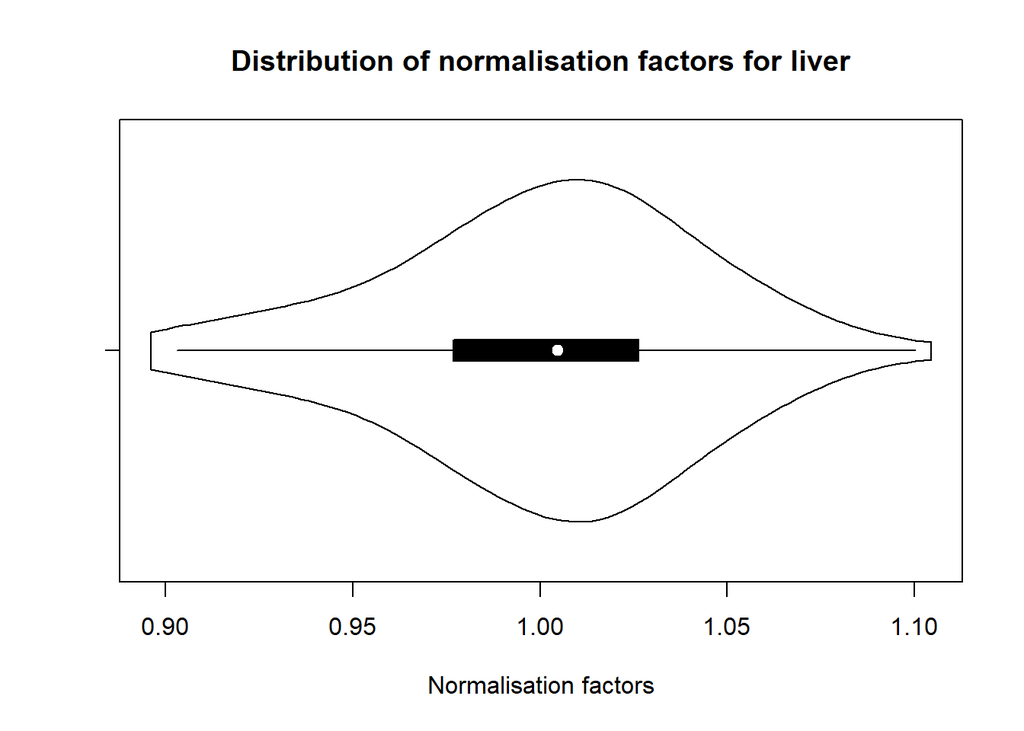

```r
title(main="Distribution of normalisation factors for liver", xlab="Normalisation factors")
```

```r
vioplot(dC$samples$norm.factors, col="white", horizontal=TRUE, names="")
```

```
## [1] 0.9642112 1.0472183
```

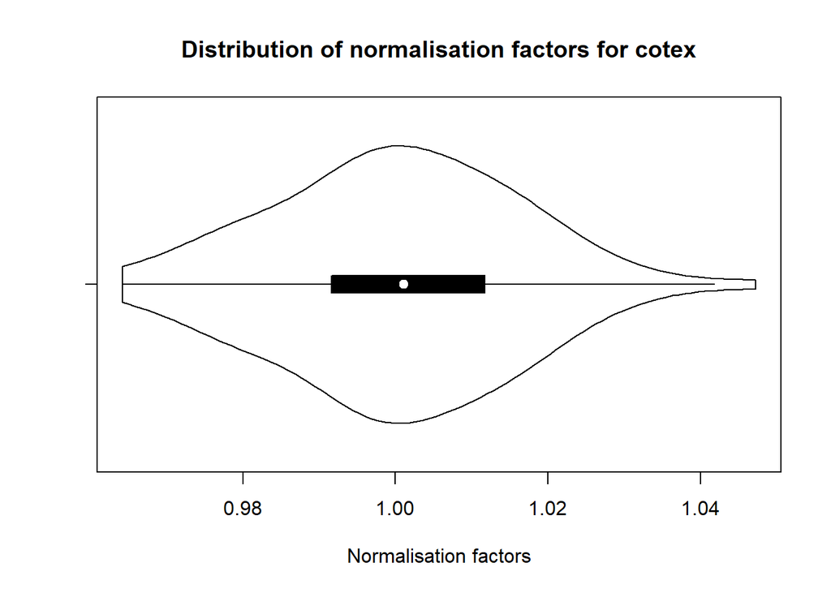

```r
title(main="Distribution of normalisation factors for cotex", xlab="Normalisation factors")
```

```r
# calculate CPM and normalize the counts
normalizedCPMcountsL <- data.frame(cpm(dL, normalized.lib.sizes=TRUE))
normalizedCPMcountsC <- data.frame(cpm(dC, normalized.lib.sizes=TRUE))

# Export normalized CPM
write.table(normalizedCPMcountsL, file="edgeR_normalized_CPM_Liver.tab", row.names=TRUE, sep="\t", quote=FALSE)
write.table(normalizedCPMcountsC, file="edgeR_normalized_CPM_Cortex.tab", row.names=TRUE, sep="\t", quote=FALSE)
```

The range of normalisation factors is between 0.8960585 and 1.1044249 for liver and between 0.9642112 and 1.0472183 for cortex. Both are close to 1, so the samples have a similar total RNA composition.

## General analysis of dataset

The goal is to compare the samples using different methods and see if it cluster by condition (SD vs NSD) or/and by mouse line.

### MDS

Multidimensional scaling (MDS) analysis. Labels are colored according to their mouse line.

#### before normalization

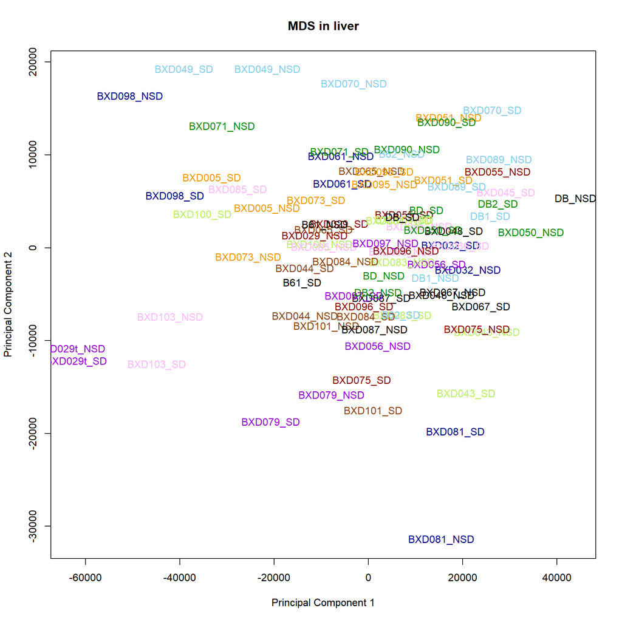

```r
# change the palette used to have color of labels that are readable
palette(c("black", "skyblue", "green4", "orange2", "darkred", "darkviolet", "darkblue", "darkolivegreen2", "chocolate4","plum1"))

# plot the MDS results
plotMDS(countsTableL_sub, main="MDS in liver", top=500, labels=keySampleL$sampleTreatment, col=as.numeric(keySampleL$strain), gene.selection="common")
```

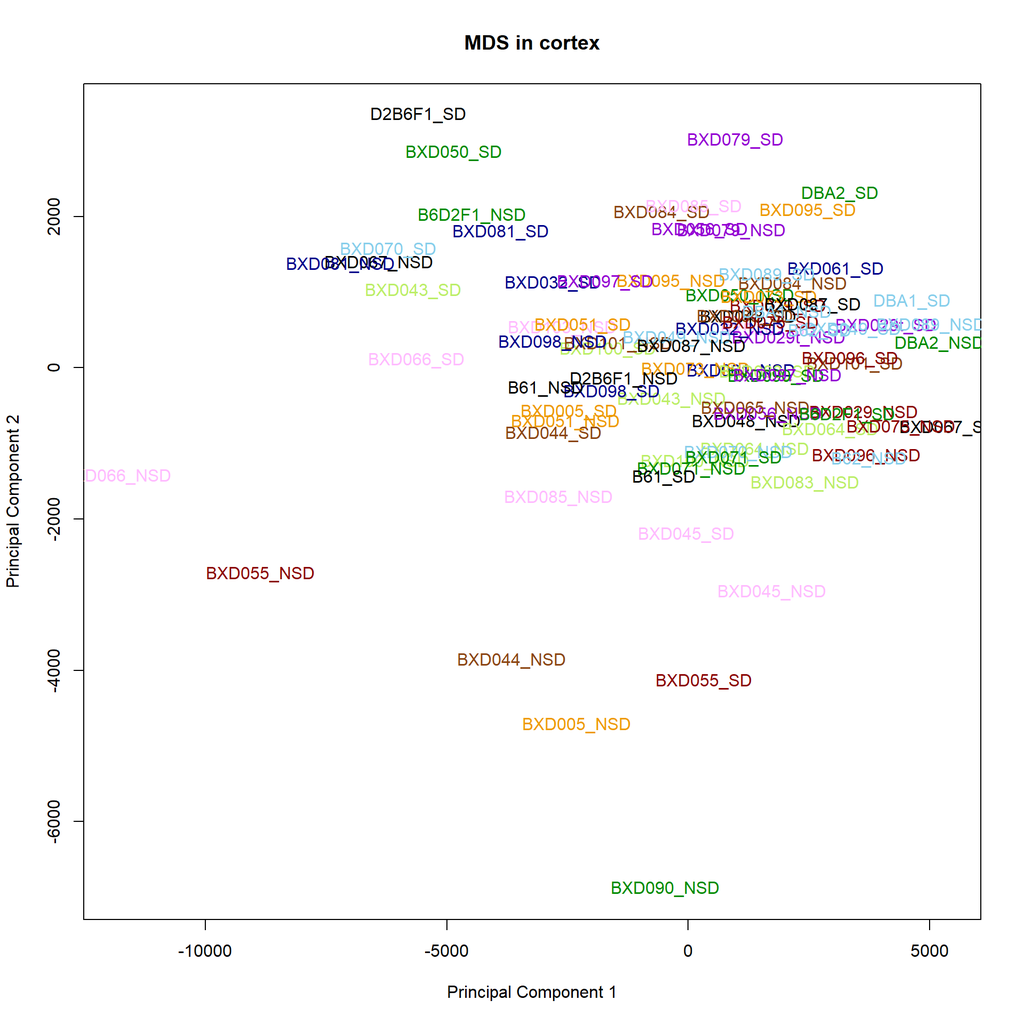

```r
plotMDS(countsTableC_sub, main="MDS in cortex", top=500, labels=keySampleC$sampleTreatment, col=as.numeric(keySampleC$strain), gene.selection="common")
```

#### after normalization

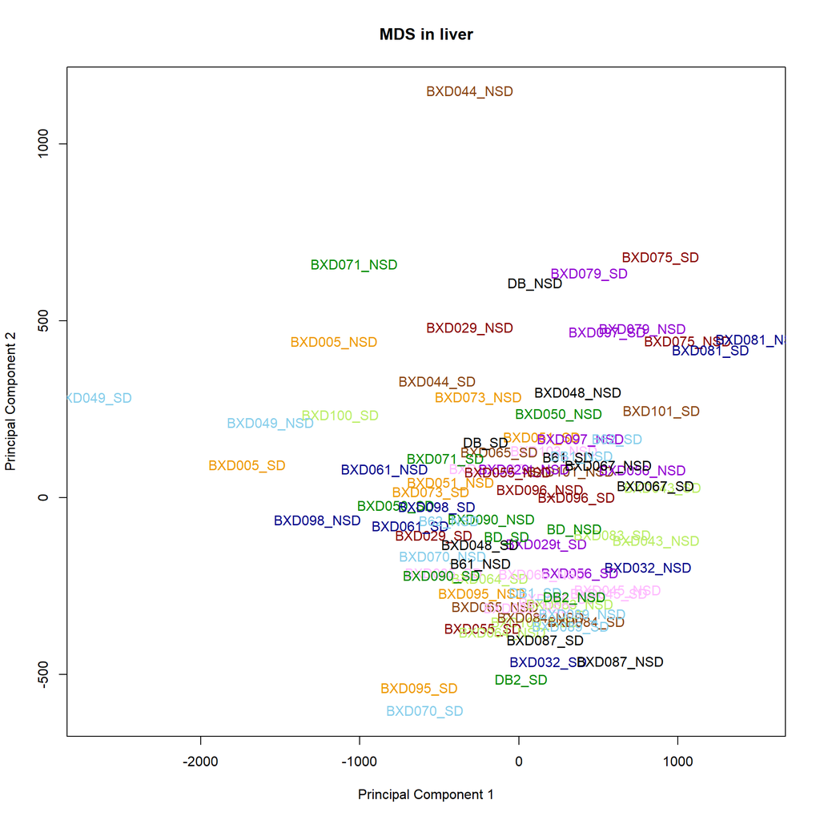

```r
# change the palette used to have color of labels that are readable
palette(c("black", "skyblue", "green4", "orange2", "darkred", "darkviolet", "darkblue", "darkolivegreen2", "chocolate4","plum1"))

# plot the MDS results
plotMDS(normalizedCPMcountsL, main="MDS in liver", top=500, labels=keySampleL$sampleTreatment, col=as.numeric(keySampleL$strain), gene.selection="common")
```

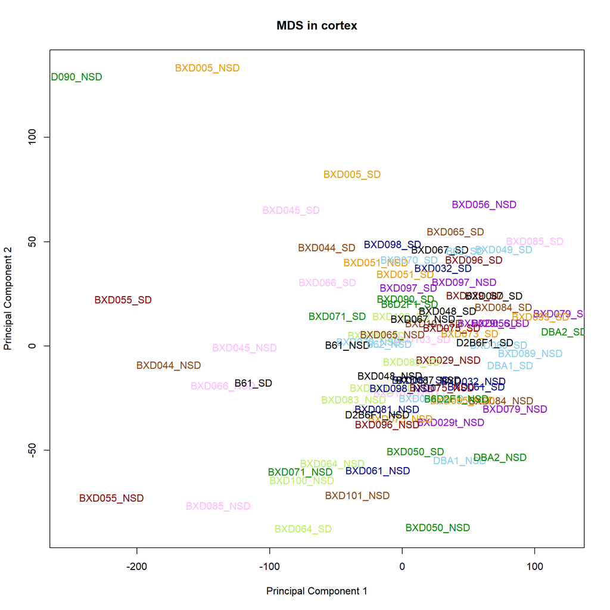

```r
plotMDS(normalizedCPMcountsC, main="MDS in cortex", top=500, labels=keySampleC$sampleTreatment, col=as.numeric(keySampleC$strain), gene.selection="common")
```

### PCA

Principal composant analysis (PCA).

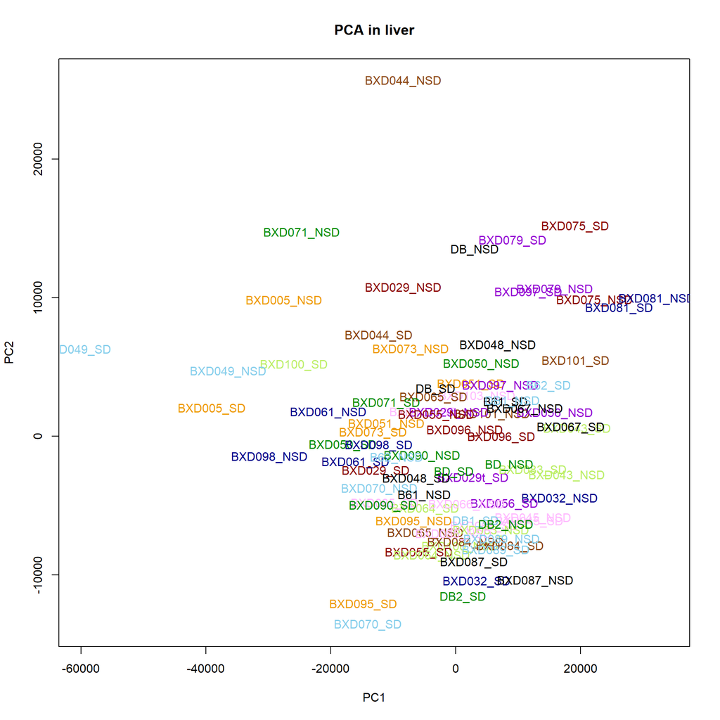

```r
# calculate PC
PC_L <- prcomp(t(normalizedCPMcountsL))
PC_C <- prcomp(t(normalizedCPMcountsC))

# plot the PCA results
plot(PC_L$x[,"PC1"], PC_L$x[,"PC2"], main="PCA in liver", xlab="PC1", ylab="PC2", pch="")
text(PC_L$x[,"PC1"], PC_L$x[,"PC2"], labels=keySampleL$sampleTreatment, pos=2, offset=-2, col=as.numeric(keySampleL$strain))
```

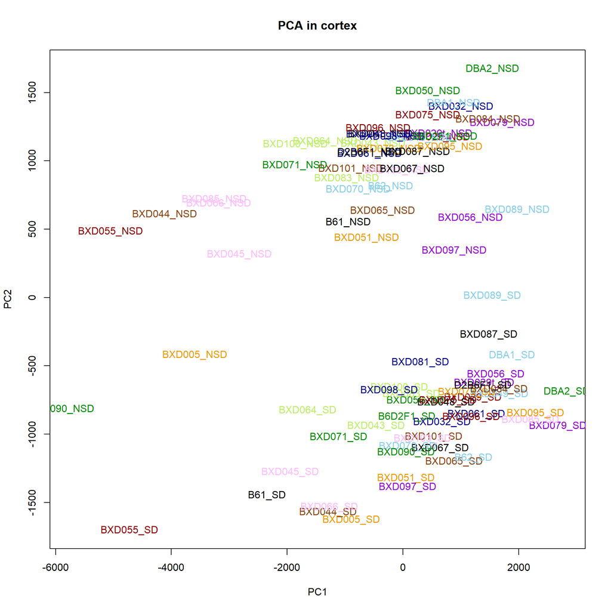

```r
plot(PC_C$x[,"PC1"], PC_C$x[,"PC2"], main="PCA in cortex", xlab="PC1", ylab="PC2", pch="")
text(PC_C$x[,"PC1"], PC_C$x[,"PC2"], labels=keySampleC$sampleTreatment, pos=2, offset=-2, col=as.numeric(keySampleC$strain))
```

### Distance

The distance between sample is calculated using euclidean distance measure.

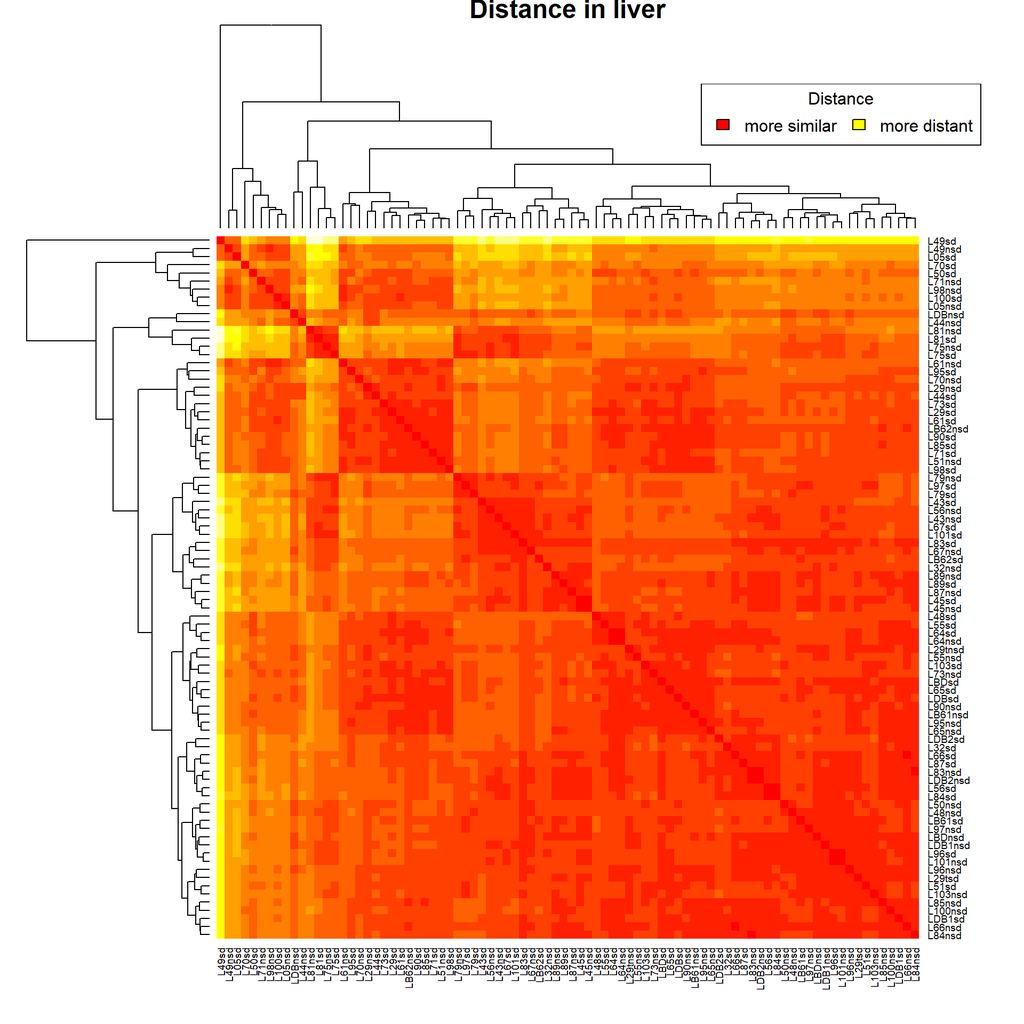

```r
# calculate the distance between samples
distsL <- dist(t(normalizedCPMcountsL))
distsC <- dist(t(normalizedCPMcountsC))

# plot the distances into a heatmap and add a quick legend
heatmap(as.matrix(distsL), main="Distance in liver", symm=TRUE, margins=c(5, 5))
legend("topright", legend=c("more similar","more distant"), horiz=TRUE, fill=heat.colors(2), title="Distance")
```

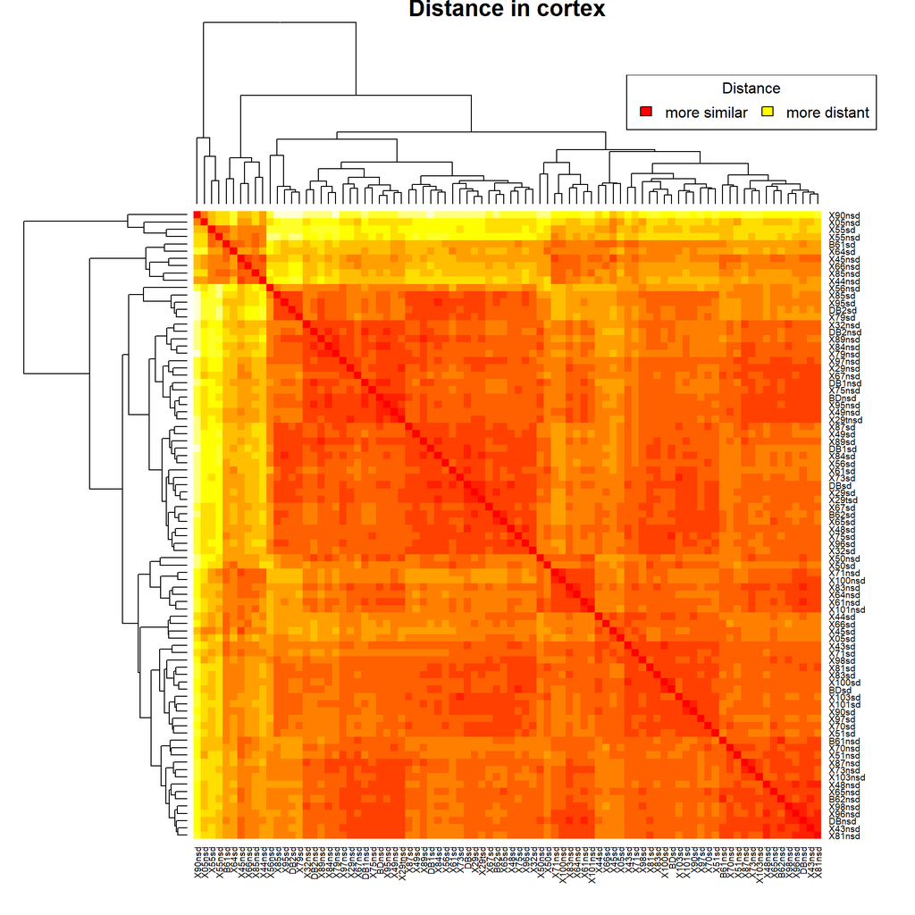

```r
heatmap(as.matrix(distsC), main="Distance in cortex", symm=TRUE, margins = c(5, 5))
legend("topright", legend=c("more similar","more distant"), horiz=TRUE, fill=heat.colors(2), title="Distance")
```

## Differential gene expression

Find which genes are up or down regulated by SD treatment (SD vs NSD).

This is done here using functions from limma package:

- model.matrix creates a model matrix (also called design matrix) which describes which samples are compared, in a voom-friendly format.
- voom prepares the data to DE analysis by considering different variances for different samples/libraries (=observations) & genes. The step are: log2CPM transformation, estimate mean-variance relationship, estimate.
- lmFit fits linear model (a line with slope and intercept) for each gene. It uses least squares fitting method (method=“ls”).
- eBayes computes statistics by empirical Bayes moderation (moderated t-statistics, moderated F-statistic, B is the log-odds). The goal is to rank genes from the more to the less differentially expressed.
- toptable extracts top ranked genes from a fit.

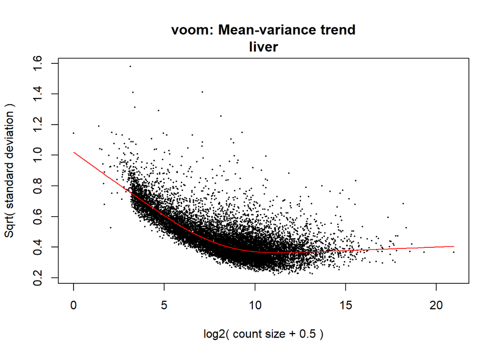

```r
# format condition vector
condsL <- factor(keySampleL$treatment)
condsC <- factor(keySampleC$treatment)

# create the design matrix by paired samples
strainL <- factor(keySampleL$strain)
strainC <- factor(keySampleC$strain)
designL <- model.matrix(~strainL+condsL)
designC <- model.matrix(~strainC+condsC)

# by default the normalization method is quantile (voom calls normalizeBetweenArrays), here TMM factors computed before are used.
# plot the mean-variance trend
resL <- voom(countsTableL_sub, designL, plot=TRUE, lib.size=colSums(countsTableL_sub)*dL$samples$norm.factors)
title(main="liver", line=0.5)
```

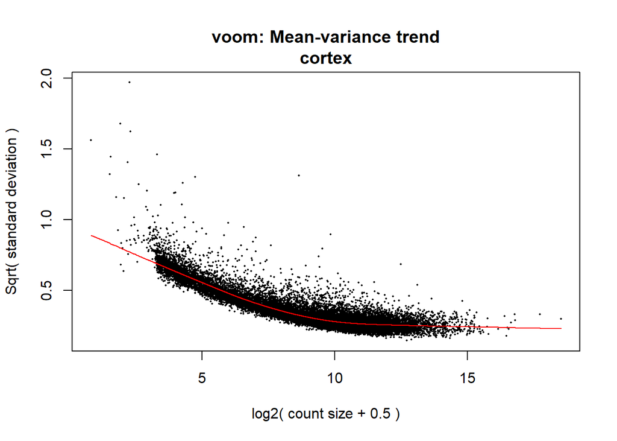

```r
resC <- voom(countsTableC_sub, designC, plot=TRUE, lib.size=colSums(countsTableC_sub)*dC$samples$norm.factors)
title(main="cortex", line=0.5)
```

```r
# fitting
# fit the linear models (one model per gene)
fitL <- lmFit(resL, designL)
fitC <- lmFit(resC, designC)
# calculate the t-statistics using empirical Bayes moderation to determine if each gene is differentially expressed.
fitL2 <- eBayes(fitL)
fitC2 <- eBayes(fitC)

# retrieve stats for each gene from the fitted models. The maximum number of genes is set higher than the number of genes tested so that all genes are taken. P-values are adjusted by FDR method, and sorted by log-odds (B)
resultTableL <- topTable(fitL2, coef="condsLSD", adjust.method="fdr", sort.by="B", number=1000000)
resultTableC <- topTable(fitC2, coef="condsCSD", adjust.method="fdr", sort.by="B", number=1000000)

# store information about DE analysis
write.table(resultTableL, file="RNA_SD_vs_NSD_DiffExp_Limma_Liver.txt", row.names=TRUE, sep="\t", quote=FALSE)
write.table(resultTableC, file="RNA_SD_vs_NSD_DiffExp_Limma_Cortex.txt", row.names=TRUE, sep="\t", quote=FALSE)
```

### MDS

Multidimensional scaling (MDS) analysis. Labels are colored according to their mouse line.

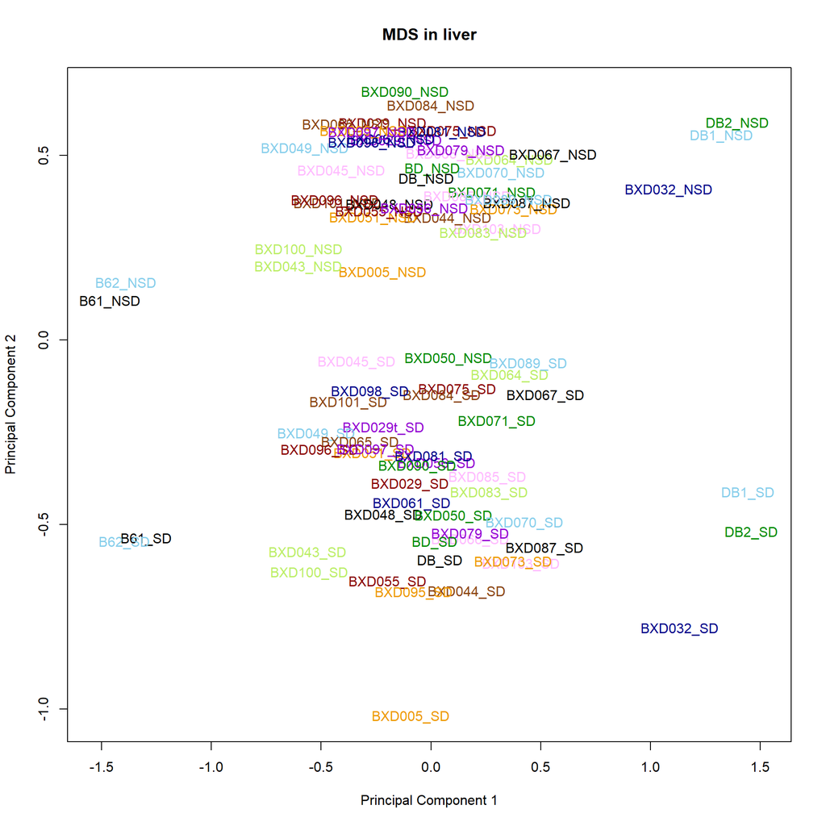

```r
# change the palette used to have color of labels that are readable
palette(c("black", "skyblue", "green4", "orange2", "darkred", "darkviolet", "darkblue", "darkolivegreen2", "chocolate4","plum1"))

# plot the MDS results
plotMDS(resL, main="MDS in liver", top=500, labels=keySampleL$sampleTreatment, col=as.numeric(keySampleL$strain), gene.selection="common")
```

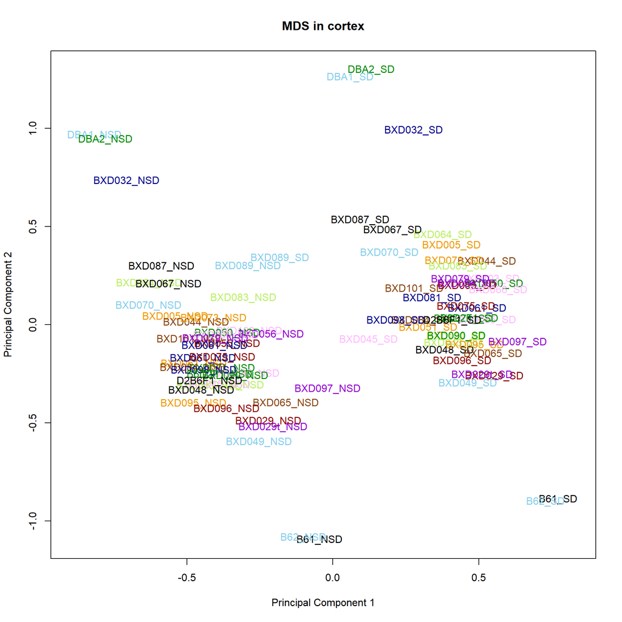

```r
plotMDS(resC, main="MDS in cortex", top=500, labels=keySampleC$sampleTreatment, col=as.numeric(keySampleC$strain), gene.selection="common")
```